# Case Study: Trends from Amazon Bestsellers

## Introduction

The following is a case study investigating bestelling books on Amazon between the years 2009 and 2019. We will look at how authors/publishers can use the trends in this data to set long-term goals.

## Contents

- Summary
  - Tools and Techniques
  - Recommendations
- Guiding Questions
- Prepare Data
- Process Data
- Analysis
- References
- Contact

## Summary

It's no secret that Amazon has become a behemoth of an organization, but it started out by starting selling books. And by the end of the time period for this data set (2019), Amazon enjoys a 50% share of all book distribution and an eBook market share around 67% ([source](https://justpublishingadvice.com/why-do-amazon-sell-more-ebooks-than-other-retailers/)). For writers and publishers around the world, it's hard to ignore Amazon's success and it seems unwise to consider not publishing to the platform.

This case study will investgiate the top 50 bestselling authors and books over the ten year period from 2009-2019. The goal is to provide insights so writers and publishers can make data-informed decisions about long-term goals.

### Guiding Questions

For this case study, our main guiding question is:

**How can trends from the Top 50 Amazon Bestsellers over a 10-year period inform long-term goals for authors and publishers?**

To address this question, we will be exploring the answering the following sub questions:

- What author(s) published the most between 2009-2019?
- What percentage of books were fiction vs. non-fiction?
- What book appears the most between 2009-2019?

### Tools and Techniques

This analysis made use of the following tools and techniques:

- Python programming language and libraries; `pandas`, `seaborn`, `numpy`, and `matplotlib`
- Data transformations: extraction, visualizations, summary statistics
- Data inspection: removal of duplicate/unnessary data, change format/datatype, verify unique values

### Recommendations

These observations led to the following recommendations outlined below.

#### Focus on high quality content

For writers/publishers, seeking to make it on these lists in the next ten years this means focusing on writing less and writing better. By slowing down to focus on higher quality content it increases your chance of your book being received well and popular.

#### For higher priced books, focus on non-fiction

A majority (73%) of the expensive books (books priced greater than 16 USD) were non-fiction. Being that non-fiction books generally require more research and effort to write, it make sense that they would be priced higher to reflect that. For authors/publishers seeking earn more, they might consider shifting their output to non-fiction books. This could be more lucrative if combined with other sources of incomes such speaking engagements, workshops, courses, etc.

#### Set price between 7 and 16 USD

This is likely to change due to inflation and increase production costs, but it should be noted that most books (75%) published during this 10-year period were under 16 USD and 50% of them were priced in this range. In other words, when choosing the book price ensure that it is within the current range of book prices -- not too high, but not too low.

## Guiding Questions

For this case study, our main guiding question is:

**How can trends from the Top 50 Amazon Bestsellers over a 10-year period inform long-term goals for authors and publishers?**

To address this question, we will be exploring the answering the following sub questions:

- What author(s) published the most between 2009-2019?
- What percentage of books were fiction vs. non-fiction?
- What book appears the most between 2009-2019?

## Prepare Data

### Dataset

The data we'll be working with is the [Amazon Top 50 Bestselling Books 2009 - 2019](https://www.kaggle.com/datasets/sootersaalu/amazon-top-50-bestselling-books-2009-2019) provided by [Scooter Saalu](https://www.kaggle.com/sootersaalu) on Kaggle.

#### Description

The dataset contains Amazon's Top 50 bestselling books from 2009 to 2019. There are 550 books with the data being categorized into fiction and non-fiction using Goodreads.

The data contains the following columns:

- **Name**: Name of the book (i.e., book title)
- **Author**: Name of the person/organization who wrote/published the book
- **User rating**: Average user rating on a scale of 1 to 5 in a given year
- **Reviews**: The total number of reviews the book received in a given
- **Year**: The year the book appeared on the bestseller list
- **Price**: The list price of the book in a given year

#### License

The data is made available to use via the [CC0: Public Domain](https://creativecommons.org/publicdomain/zero/1.0/) license which allows anyone to "copy, modify, distribute and perform the work, even for commercial purposes, all without asking permission".

## Process Data

Let's import our libraries and start processing our data. We will look for the following abnormalities:

- Check for missing values
- Investigate outliers
- Confirm data types

```python
import numpy as np
import pandas as pd
import matplotlib.pyplot as plt
import seaborn as sns
```

### Quick overview

```python
df = pd.read_csv('amazon_bestsellers_2009-2019.csv')
```

```python
df.shape
```

```
(550, 7)
```

```python
df.head()
```

|  | Name | Author | User Rating | Reviews | Price | Year | Genre |
| --- | --- | --- | --- | --- | --- | --- | --- |
| 0 | 10-Day Green Smoothie Cleanse | JJ Smith | 4.7 | 17350 | 8 | 2016 | Non Fiction |
| 1 | 11/22/63: A Novel | Stephen King | 4.6 | 2052 | 22 | 2011 | Fiction |
| 2 | 12 Rules for Life: An Antidote to Chaos | Jordan B. Peterson | 4.7 | 18979 | 15 | 2018 | Non Fiction |
| 3 | 1984 (Signet Classics) | George Orwell | 4.7 | 21424 | 6 | 2017 | Fiction |
| 4 | 5,000 Awesome Facts (About Everything!) (Natio... | National Geographic Kids | 4.8 | 7665 | 12 | 2019 | Non Fiction |

```python
df.describe()
```

|  | User Rating | Reviews | Price | Year |
| --- | --- | --- | --- | --- |
| count | 550.000000 | 550.000000 | 550.000000 | 550.000000 |
| mean | 4.618364 | 11953.281818 | 13.100000 | 2014.000000 |
| std | 0.226980 | 11731.132017 | 10.842262 | 3.165156 |
| min | 3.300000 | 37.000000 | 0.000000 | 2009.000000 |
| 25% | 4.500000 | 4058.000000 | 7.000000 | 2011.000000 |
| 50% | 4.700000 | 8580.000000 | 11.000000 | 2014.000000 |
| 75% | 4.800000 | 17253.250000 | 16.000000 | 2017.000000 |
| max | 4.900000 | 87841.000000 | 105.000000 | 2019.000000 |

### Check for missing values

```python
df.isnull().sum()
```

```
Name           0
Author         0
User Rating    0
Reviews        0
Price          0
Year           0
Genre          0
dtype: int64
```

**Observations**

No missing values found.

### Investigate outliers

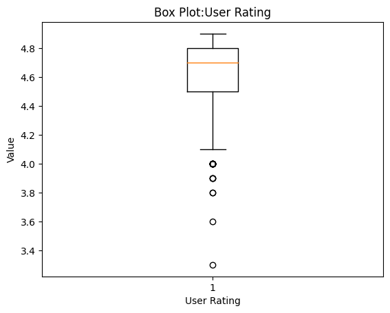

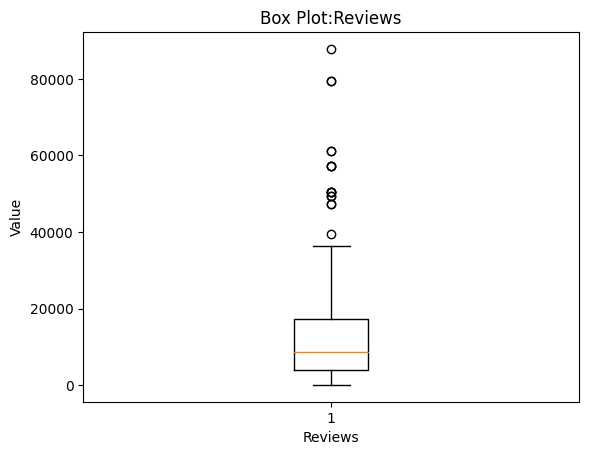

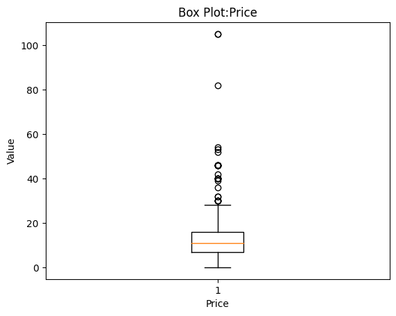

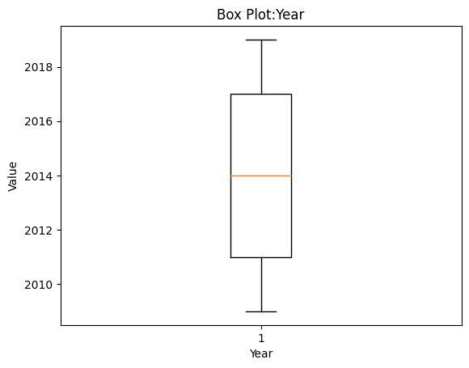

```python
columns_to_plot = ['User Rating', 'Reviews', 'Price', 'Year']
for column_name in columns_to_plot:
    plt.boxplot(df[column_name])
    plt.title('Box Plot:' + column_name)
    plt.xlabel(column_name)
    plt.ylabel('Value')
    plt.show()
```

**Observations**

Price, User Ratings, and Reviews have outliers. However, this is to be expected since there would be variablity in book prices as well as the number of ratings and reviews a book receives. Further, the outliers presented in the data do not seem unreasonable given the context of the data.

### Confirm data types

```python
df.dtypes
```

```
Name            object
Author          object
User Rating    float64
Reviews          int64
Price            int64
Year             int64
Genre           object
dtype: object
```

**Observations**

No abnormal data types.

### Process Conlcusions

- No missing values; contains 550 entries (as described in the source)
- The max and min of the year matches what is the data description
- The data types for each column match what is described (i.e., numbers are numbers, categorical data are objects/strings)

## Analysis

### Correlation Heatmap

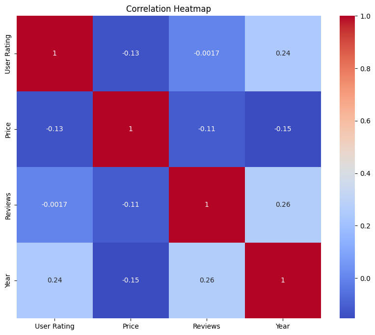

```python
correlation_matrix = df[['User Rating', 'Price', 'Reviews', 'Year']].corr()

plt.figure(figsize=(10,8))

sns.heatmap(correlation_matrix, annot=True, cmap='coolwarm')

plt.title('Correlation Heatmap')

plt.show()
```

**Observations**

Little or no correllation between User Rating, Price, and Reviews.

### Genre

```
Non Fiction    310
Fiction        240
Name: Genre, dtype: int64
```

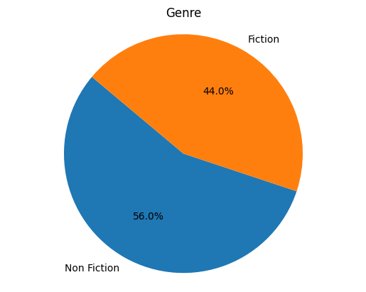

```python
genre = df["Genre"].value_counts()
print(genre)

percent_non_fic = round(((genre['Non Fiction'] / 550) * 100))
percent_fic = round(((genre['Fiction'] / 550) * 100))

sizes = [percent_non_fic, percent_fic]
labels = ['Non Fiction', 'Fiction']

plt.pie(sizes, labels=labels, autopct='%1.1f%%', startangle=140)
plt.axis('equal')
plt.title('Genre')
plt.show()
```

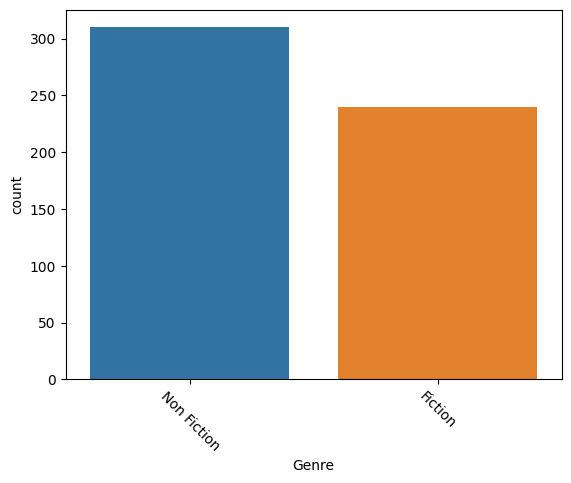

```python
sns.countplot(x='Genre', data=df)

plt.xticks(rotation=-45)

plt.show()
```

**Observations**

- Most books are non-fiction, but only by a slight majority
  - Non Fiction: 56%
  - Fiction: 44%

### Price

#### Summary Statistics

```python
df["Price"].describe()
```

```
count    550.000000
mean      13.100000
std       10.842262
min        0.000000
25%        7.000000
50%       11.000000
75%       16.000000
max      105.000000
Name: Price, dtype: float64
```

#### Box plot

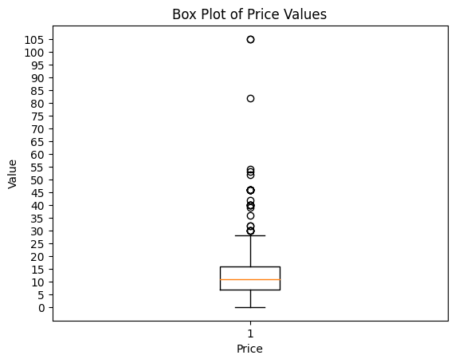

```python
plt.boxplot(df['Price'])
plt.title('Box Plot of Price Values')
plt.xlabel('Price')
plt.ylabel('Value')
plt.yticks(range(0, 110, 5))
plt.show()
```

#### Histogram

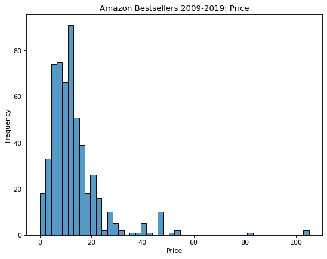

```python
plt.figure(figsize=(8,6), dpi=80)
sns.histplot(data=df["Price"], bins='auto')

plt.title('Amazon Bestsellers 2009-2019: Price')
plt.xlabel('Price')
plt.ylabel('Frequency')

plt.show()
```

**Observations**

- 50% of the price values for books are between 7 USD and 16 USD.
- Outliers are greater than 30 USD

#### Expensive Books

For our purposes we will define a book as expensive it costs more than 16 USD since 75% of books in our data set cost less than that.

```python
expensive_books_sorted = df.loc[df['Price']>16].sort_values(by='Price', ascending=False)

num_expensive_books = len(expensive_books_sorted)

print(num_expensive_books, 'books sold for more than 16 USD')
expensive_books_sorted
```

```
122 books sold for more than 16 USD
```

|  | Name | Author | User Rating | Reviews | Price | Year | Genre |
| --- | --- | --- | --- | --- | --- | --- | --- |
| 69 | Diagnostic and Statistical Manual of Mental Di... | American Psychiatric Association | 4.5 | 6679 | 105 | 2013 | Non Fiction |
| 70 | Diagnostic and Statistical Manual of Mental Di... | American Psychiatric Association | 4.5 | 6679 | 105 | 2014 | Non Fiction |
| 473 | The Twilight Saga Collection | Stephenie Meyer | 4.7 | 3801 | 82 | 2009 | Fiction |
| 151 | Hamilton: The Revolution | Lin-Manuel Miranda | 4.9 | 5867 | 54 | 2016 | Non Fiction |
| 346 | The Book of Basketball: The NBA According to T... | Bill Simmons | 4.7 | 858 | 53 | 2009 | Non Fiction |
| ... | ... | ... | ... | ... | ... | ... | ... |
| 311 | StrengthsFinder 2.0 | Gallup | 4.0 | 5069 | 17 | 2016 | Non Fiction |
| 446 | The Pioneer Woman Cooks: A Year of Holidays: 1... | Ree Drummond | 4.8 | 2663 | 17 | 2013 | Non Fiction |
| 312 | StrengthsFinder 2.0 | Gallup | 4.0 | 5069 | 17 | 2017 | Non Fiction |
| 342 | The Big Short: Inside the Doomsday Machine | Michael Lewis | 4.7 | 3536 | 17 | 2010 | Non Fiction |
| 307 | StrengthsFinder 2.0 | Gallup | 4.0 | 5069 | 17 | 2012 | Non Fiction |

122 rows × 7 columns

##### Summary Statistics

```python
expensive_books_sorted['Price'].describe()
```

```
count    122.000000
mean      27.172131
std       14.925541
min       17.000000
25%       18.000000
50%       21.000000
75%       29.500000
max      105.000000
Name: Price, dtype: float64
```

##### Box plot

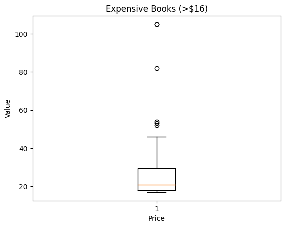

```python
plt.boxplot(expensive_books_sorted['Price'])
plt.title('Expensive Books (>$16)')
plt.xlabel('Price')
plt.ylabel('Value')

plt.show()
```

##### Pie chart

```
Non Fiction    89
Fiction        33
Name: Genre, dtype: int64
```

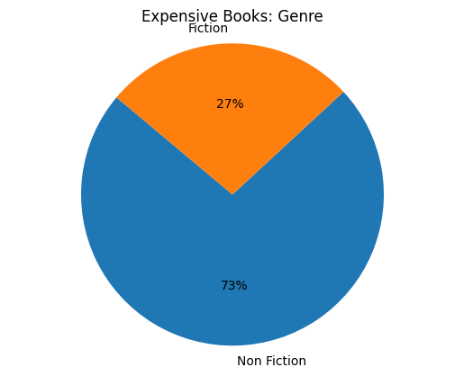

```python
expensive_books_genre = expensive_books_sorted['Genre'].value_counts()
percent_non_fic_expensive = round((expensive_books_genre['Non Fiction'] / num_expensive_books) * 100)
percent_fic_expensive = round((expensive_books_genre['Fiction'] / num_expensive_books) * 100)

print(expensive_books_genre)

# pie chart of genre for expensive books
genre_percents_expensive = [percent_non_fic_expensive, percent_fic_expensive]
genre_labels_expensive = ['Non Fiction', 'Fiction']

plt.pie(genre_percents_expensive, labels=genre_labels_expensive, autopct='%1.0f%%', startangle=140)
plt.axis('equal')
plt.title('Expensive Books: Genre')

plt.show()
```

##### Highest priced book

```python
df.loc[df["Price"]==105]
```

|  | Name | Author | User Rating | Reviews | Price | Year | Genre |
| --- | --- | --- | --- | --- | --- | --- | --- |
| 69 | Diagnostic and Statistical Manual of Mental Di... | American Psychiatric Association | 4.5 | 6679 | 105 | 2013 | Non Fiction |
| 70 | Diagnostic and Statistical Manual of Mental Di... | American Psychiatric Association | 4.5 | 6679 | 105 | 2014 | Non Fiction |

##### Observations

- The two highest priced books (Diagnostic and Statistics Manual... 105 USD, Twilight Saga 82 USD) are 50 USD more expensive than 75% of all the expensive books
- A majority (73%) of expensive books are non fiction

#### Inexpensive Books

```python
inexpensive_books_sorted = df.loc[df["Price"]<=7].sort_values(by='Price', ascending=False)
num_inexpensive_books = len(inexpensive_books_sorted)

print(num_inexpensive_books, "books sold for 7 USD or less", )
inexpensive_books_sorted
```

```
148 books sold for 7 USD or less
```

|  | Name | Author | User Rating | Reviews | Price | Year | Genre |
| --- | --- | --- | --- | --- | --- | --- | --- |
| 147 | Goodnight, Goodnight Construction Site (Hardco... | Sherri Duskey Rinker | 4.9 | 7038 | 7 | 2013 | Fiction |
| 399 | The Handmaid's Tale | Margaret Atwood | 4.3 | 29442 | 7 | 2017 | Fiction |
| 367 | The Fault in Our Stars | John Green | 4.7 | 50482 | 7 | 2014 | Fiction |
| 146 | Goodnight, Goodnight Construction Site (Hardco... | Sherri Duskey Rinker | 4.9 | 7038 | 7 | 2012 | Fiction |
| 283 | Quiet: The Power of Introverts in a World That... | Susan Cain | 4.6 | 10009 | 7 | 2013 | Non Fiction |
| ... | ... | ... | ... | ... | ... | ... | ... |
| 381 | The Getaway | Jeff Kinney | 4.8 | 5836 | 0 | 2017 | Fiction |
| 116 | Frozen (Little Golden Book) | RH Disney | 4.7 | 3642 | 0 | 2014 | Fiction |
| 42 | Cabin Fever (Diary of a Wimpy Kid, Book 6) | Jeff Kinney | 4.8 | 4505 | 0 | 2011 | Fiction |
| 358 | The Constitution of the United States | Delegates of the Constitutional | 4.8 | 2774 | 0 | 2016 | Non Fiction |
| 71 | Diary of a Wimpy Kid: Hard Luck, Book 8 | Jeff Kinney | 4.8 | 6812 | 0 | 2013 | Fiction |

148 rows × 7 columns

##### Summary Statistics

```python
inexpensive_books_sorted['Price'].describe()
```

```
count    148.000000
mean       4.804054
std        1.883183
min        0.000000
25%        4.000000
50%        5.000000
75%        6.000000
max        7.000000
Name: Price, dtype: float64
```

##### Box plot

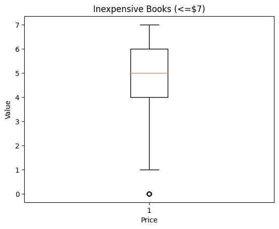

```python
plt.boxplot(inexpensive_books_sorted['Price'])
plt.title('Inexpensive Books (<=$7)')
plt.xlabel('Price')
plt.ylabel('Value')

plt.show()
```

##### Pie chart

```
Fiction        83
Non Fiction    65
Name: Genre, dtype: int64
```

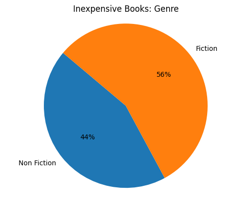

```python
inexpensive_books_genre = inexpensive_books_sorted['Genre'].value_counts()

percent_non_fic_inexpensive = round((inexpensive_books_genre['Non Fiction'] / num_inexpensive_books) * 100)
percent_fic_inexpensive = round((inexpensive_books_genre['Fiction'] / num_inexpensive_books) * 100)

print(inexpensive_books_genre)

# pie chart of genre for inexpesnive books
genre_percents_inexpensive = [percent_non_fic_inexpensive, percent_fic_inexpensive]
genre_labels_inexpensive = ['Non Fiction', 'Fiction']

plt.pie(genre_percents_inexpensive, labels=genre_labels_inexpensive, autopct='%1.0f%%', startangle=140)
plt.axis('equal')
plt.title('Inexpensive Books: Genre')

plt.show()
```

##### Free books

```python
print(len(df.loc[df["Price"]==0]), "books sold for free")
df.loc[df["Price"]==0]
```

```
12 books sold for free
```

|  | Name | Author | User Rating | Reviews | Price | Year | Genre |
| --- | --- | --- | --- | --- | --- | --- | --- |
| 42 | Cabin Fever (Diary of a Wimpy Kid, Book 6) | Jeff Kinney | 4.8 | 4505 | 0 | 2011 | Fiction |
| 71 | Diary of a Wimpy Kid: Hard Luck, Book 8 | Jeff Kinney | 4.8 | 6812 | 0 | 2013 | Fiction |
| 116 | Frozen (Little Golden Book) | RH Disney | 4.7 | 3642 | 0 | 2014 | Fiction |
| 193 | JOURNEY TO THE ICE P | RH Disney | 4.6 | 978 | 0 | 2014 | Fiction |
| 219 | Little Blue Truck | Alice Schertle | 4.9 | 1884 | 0 | 2014 | Fiction |
| 358 | The Constitution of the United States | Delegates of the Constitutional | 4.8 | 2774 | 0 | 2016 | Non Fiction |
| 381 | The Getaway | Jeff Kinney | 4.8 | 5836 | 0 | 2017 | Fiction |
| 461 | The Short Second Life of Bree Tanner: An Eclip... | Stephenie Meyer | 4.6 | 2122 | 0 | 2010 | Fiction |
| 505 | To Kill a Mockingbird | Harper Lee | 4.8 | 26234 | 0 | 2013 | Fiction |
| 506 | To Kill a Mockingbird | Harper Lee | 4.8 | 26234 | 0 | 2014 | Fiction |
| 507 | To Kill a Mockingbird | Harper Lee | 4.8 | 26234 | 0 | 2015 | Fiction |
| 508 | To Kill a Mockingbird | Harper Lee | 4.8 | 26234 | 0 | 2016 | Fiction |

```python
print(len(df.loc[df["Price"]==1]), "book sold for 1 USD")
df.loc[df["Price"]==1]
```

```
1 book sold for 1 USD
```

|  | Name | Author | User Rating | Reviews | Price | Year | Genre |
| --- | --- | --- | --- | --- | --- | --- | --- |
| 91 | Eat This Not That! Supermarket Survival Guide:... | David Zinczenko | 4.5 | 720 | 1 | 2009 | Non Fiction |

##### Observations

- Some books appear multiple years in a row (e.g., 'To Kill a Mockingbird')
- A majority (75%) of inexpensive books are priced between 4 USD and 7 USD
- A slight majority (56%) of inexpensive books are fiction

### User Rating

#### Bar graph

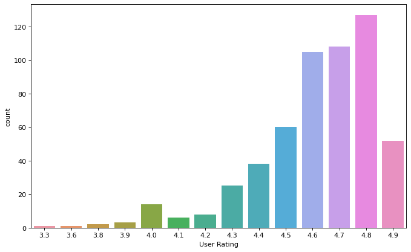

```python
plt.figure(figsize=(10, 6), dpi=80)
sns.countplot(x='User Rating', data=df)

plt.show()
```

#### Summary Statistics

```python
df['User Rating'].describe()
```

```
count    550.000000
mean       4.618364
std        0.226980
min        3.300000
25%        4.500000
50%        4.700000
75%        4.800000
max        4.900000
Name: User Rating, dtype: float64
```

#### Box plot

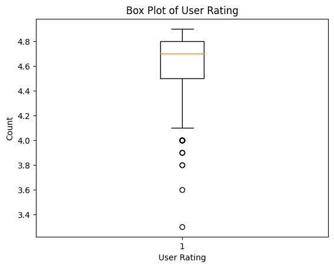

```python
plt.boxplot(df['User Rating'])
plt.title('Box Plot of User Rating')
plt.xlabel('User Rating')
plt.ylabel('Count')
plt.show()
```

#### Highest Rated Books

For our purposes, we will define the highest rated books as any books that have a 'User Rating' of 4.9 since most books (75%) have a rating below value.

```python
highest_rated_books = df.loc[df['User Rating']==4.9]
list_of_highest_rated_books = highest_rated_books['Name'].value_counts().index.tolist()

for book in list_of_highest_rated_books:
    print(book)
```

```
Oh, the Places You'll Go!
The Very Hungry Caterpillar
Jesus Calling: Enjoying Peace in His Presence (with Scripture References)
The Wonderful Things You Will Be
Goodnight, Goodnight Construction Site (Hardcover Books for Toddlers, Preschool Books for Kids)
Brown Bear, Brown Bear, What Do You See?
Dog Man: Brawl of the Wild: From the Creator of Captain Underpants (Dog Man #6)
Dog Man: Lord of the Fleas: From the Creator of Captain Underpants (Dog Man #5)
Dog Man: For Whom the Ball Rolls: From the Creator of Captain Underpants (Dog Man #7)
Unfreedom of the Press
Dog Man: A Tale of Two Kitties: From the Creator of Captain Underpants (Dog Man #3)
The Magnolia Story
The Legend of Zelda: Hyrule Historia
Strange Planet (Strange Planet Series)
Rush Revere and the First Patriots: Time-Travel Adventures With Exceptional Americans (2)
Rush Revere and the Brave Pilgrims: Time-Travel Adventures with Exceptional Americans (1)
Dog Man: Fetch-22: From the Creator of Captain Underpants (Dog Man #8)
Obama: An Intimate Portrait
Little Blue Truck
Last Week Tonight with John Oliver Presents A Day in the Life of Marlon Bundo (Better Bundo Book, LGBT Childrens Book)
Dog Man and Cat Kid: From the Creator of Captain Underpants (Dog Man #4)
Humans of New York : Stories
Harry Potter and the Sorcerer's Stone: The Illustrated Edition (Harry Potter, Book 1)
Harry Potter and the Prisoner of Azkaban: The Illustrated Edition (Harry Potter, Book 3)
Harry Potter and the Goblet of Fire: The Illustrated Edition (Harry Potter, Book 4) (4)
Harry Potter and the Chamber of Secrets: The Illustrated Edition (Harry Potter, Book 2)
Hamilton: The Revolution
Wrecking Ball (Diary of a Wimpy Kid Book 14)
```

**Observations**

- 50% of User Rating are between 4.5 and 4.8
- Outliers are less than 4.1

### Reviews

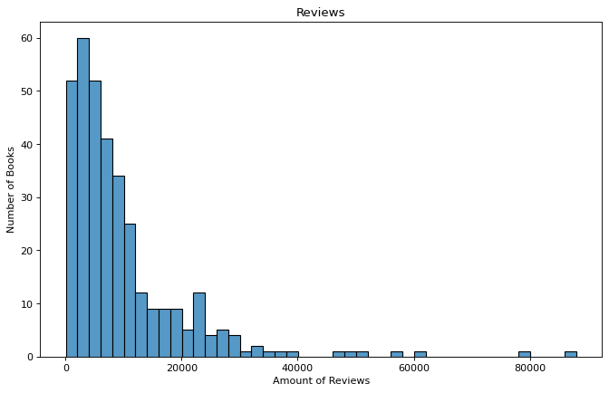

```python
# create series for value counts
review_counts = df['Reviews'].value_counts()

# convert series to data frame
review_counts_df = pd.DataFrame({'num_reviews': review_counts.index, 'num_books': review_counts.values})

# create histogram of reviews
plt.figure(figsize=(10,6), dpi=80)
sns.histplot(data=review_counts_df['num_reviews'], bins='auto', binwidth=2000)
plt.title('Reviews')
plt.xlabel('Amount of Reviews')
plt.ylabel('Number of Books')

plt.show()
```

```python
review_counts_df['num_reviews'].describe()
```

```
count      346.000000
mean      9786.430636
std      10871.900146
min         37.000000
25%       3362.750000
50%       6361.500000
75%      11510.250000
max      87841.000000
Name: num_reviews, dtype: float64
```

#### Books with Most Number of Reviews

```python
highest_reviews = df.loc[df['Reviews']>11510]
list_of_highest_reviews = highest_reviews['Name'].value_counts().index.tolist()

print(len(list_of_highest_reviews), 'book have greater than 11,510 reviews')

for book in list_of_highest_reviews:
    print(book)
```

```
88 book have greater than 11,510 reviews
Oh, the Places You'll Go!
The Very Hungry Caterpillar
The Four Agreements: A Practical Guide to Personal Freedom (A Toltec Wisdom Book)
Jesus Calling: Enjoying Peace in His Presence (with Scripture References)
First 100 Words
Wonder
Unbroken: A World War II Story of Survival, Resilience, and Redemption
To Kill a Mockingbird
The 5 Love Languages: The Secret to Love that Lasts
How to Win Friends & Influence People
Giraffes Can't Dance
The Life-Changing Magic of Tidying Up: The Japanese Art of Decluttering and Organizing
The Help
The Fault in Our Stars
You Are a Badass: How to Stop Doubting Your Greatness and Start Living an Awesome Life
The Great Gatsby
Catching Fire (The Hunger Games)
Mockingjay (The Hunger Games)
The Subtle Art of Not Giving a F*ck: A Counterintuitive Approach to Living a Good Life
Player's Handbook (Dungeons & Dragons)
Gone Girl
Milk and Honey
The Book Thief
The Art of Racing in the Rain: A Novel
The Hunger Games (Book 1)
The Boys in the Boat: Nine Americans and Their Epic Quest for Gold at the 1936 Berlin Olympics
Love You Forever
The Hunger Games Trilogy Boxed Set (1)
The Complete Ketogenic Diet for Beginners: Your Essential Guide to Living the Keto Lifestyle
School Zone - Big Preschool Workbook - Ages 4 and Up, Colors, Shapes, Numbers 1-10, Alphabet, Pre-Writing, Pre-Reading…
Ready Player One: A Novel
Proof of Heaven: A Neurosurgeon's Journey into the Afterlife
All the Light We Cannot See
A Man Called Ove: A Novel
The Nightingale: A Novel
The Girl on the Train
The Goldfinch: A Novel (Pulitzer Prize for Fiction)
Becoming
The Shack: Where Tragedy Confronts Eternity
```

[output cut: 34 more lines]

```
Grey: Fifty Shades of Grey as Told by Christian (Fifty Shades of Grey Series)
Harry Potter and the Chamber of Secrets: The Illustrated Edition (Harry Potter, Book 2)
Harry Potter and the Cursed Child, Parts 1 & 2, Special Rehearsal Edition Script
Can't Hurt Me: Master Your Mind and Defy the Odds
And the Mountains Echoed
Inferno
Last Week Tonight with John Oliver Presents A Day in the Life of Marlon Bundo (Better Bundo Book, LGBT Childrens Book)
Little Fires Everywhere
12 Rules for Life: An Antidote to Chaos
Origin: A Novel (Robert Langdon)
Orphan Train
Doctor Sleep: A Novel
The Alchemist
The Body Keeps the Score: Brain, Mind, and Body in the Healing of Trauma
10-Day Green Smoothie Cleanse
```

```python
highest_reviews_sorted = highest_reviews.sort_values(by='Reviews', ascending=False)
list_of_top_10_highest_reviews = highest_reviews_sorted['Name'].value_counts().head(10).index.tolist()

for book in list_of_top_10_highest_reviews:
    print(book)
```

```
Oh, the Places You'll Go!
The Very Hungry Caterpillar
Jesus Calling: Enjoying Peace in His Presence (with Scripture References)
The Four Agreements: A Practical Guide to Personal Freedom (A Toltec Wisdom Book)
How to Win Friends & Influence People
The 5 Love Languages: The Secret to Love that Lasts
Wonder
First 100 Words
To Kill a Mockingbird
Giraffes Can't Dance
```

### Author

Let's investigate how many times an author published between 2009-2019 and which authors published the most during this time period.

```python
author_counts = df["Author"].value_counts()
print(author_counts)
```

```
Jeff Kinney                           12
Gary Chapman                          11
Rick Riordan                          11
Suzanne Collins                       11
American Psychological Association    10
                                      ..
Keith Richards                         1
Chris Cleave                           1
Alice Schertle                         1
Celeste Ng                             1
Adam Gasiewski                         1
Name: Author, Length: 248, dtype: int64
```

#### Summary Statistics

```python
author_counts.describe()
```

```
count    248.000000
mean       2.217742
std        2.046268
min        1.000000
25%        1.000000
50%        1.000000
75%        2.000000
max       12.000000
Name: Author, dtype: float64
```

#### Box plot

In this box plot, we can see how many times a bestselling author published a book between 2009 and 2019.

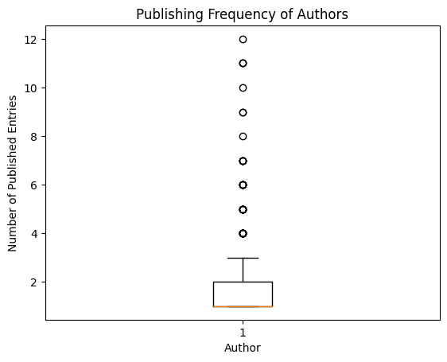

```python
plt.boxplot(author_counts)
plt.title('Publishing Frequency of Authors')
plt.xlabel('Author')
plt.ylabel('Number of Published Entries')

plt.show()
```

#### Most Frequent Authors

For our purposes, we will define the most frequent authors as those who published more than twice.

```python
mask_authors = author_counts>2
authors_most_frequent = author_counts[mask_authors]

print(len(authors_most_frequent), 'authors published more than two books from 2009-2019')
print(authors_most_frequent)
```

```
58 authors published more than two books from 2009-2019
Jeff Kinney                           12
Gary Chapman                          11
Rick Riordan                          11
Suzanne Collins                       11
American Psychological Association    10
Dr. Seuss                              9
Gallup                                 9
Rob Elliott                            8
Stephen R. Covey                       7
Stephenie Meyer                        7
Dav Pilkey                             7
Bill O'Reilly                          7
Eric Carle                             7
The College Board                      6
E L James                              6
Don Miguel Ruiz                        6
J.K. Rowling                           6
Stieg Larsson                          6
Sarah Young                            6
Harper Lee                             6
Laura Hillenbrand                      5
R. J. Palacio                          5
Dale Carnegie                          5
Patrick Lencioni                       5
Giles Andreae                          5
Roger Priddy                           5
John Green                             5
John Grisham                           5
Marie Kondō                            4
Rupi Kaur                              4
Rod Campbell                           4
Charlaine Harris                       4
Jim Collins                            4
Kathryn Stockett                       4
Emily Winfield Martin                  4
Stephen King                           4
Jen Sincero                            4
Malcolm Gladwell                       4
Thug Kitchen                           4
Veronica Roth                          4
Glenn Beck                             3
Drew Daywalt                           3
Rachel Hollis                          3
Walter Isaacson                        3
Gillian Flynn                          3
Dan Brown                              3
Rebecca Skloot                         3
Melissa Hartwig Urban                  3
Mark Manson                            3
Margaret Wise Brown                    3
George R.R. Martin                     3
F. Scott Fitzgerald                    3
Wizards RPG Team                       3
Ina Garten                             3
Brandon Stanton                        3
Ree Drummond                           3
Carol S. Dweck                         3
Francis Chan                           3
Name: Author, dtype: int64
```

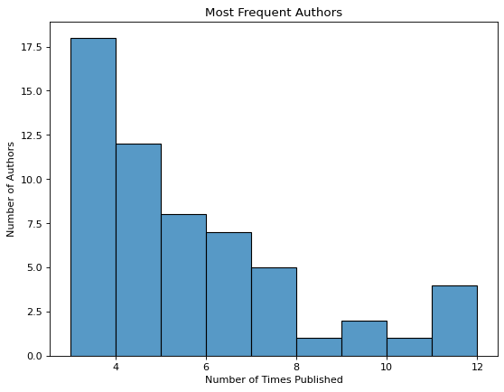

```python
plt.figure(figsize=(8, 6), dpi=80)
sns.histplot(data=authors_most_frequent, bins='auto', binwidth=1)

plt.title('Most Frequent Authors')
plt.xlabel('Number of Times Published')
plt.ylabel('Number of Authors')

plt.show()
```

#### Top 10 Authors

```python
top_ten_authors = authors_most_frequent.head(10)
print(top_ten_authors)
```

```
Jeff Kinney                           12
Gary Chapman                          11
Rick Riordan                          11
Suzanne Collins                       11
American Psychological Association    10
Dr. Seuss                              9
Gallup                                 9
Rob Elliott                            8
Stephen R. Covey                       7
Stephenie Meyer                        7
Name: Author, dtype: int64
```

##### Bar plot

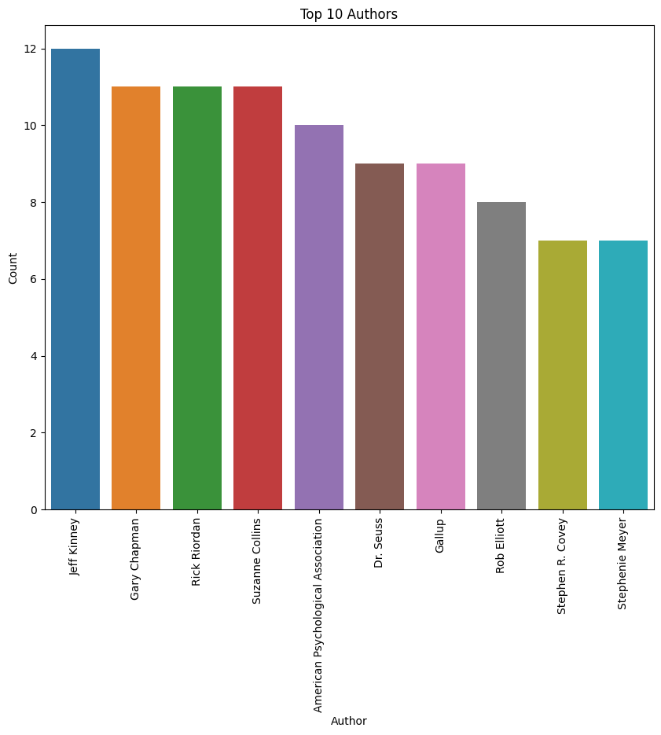

```python
# convert series to data frame
top_ten_authors_df = pd.DataFrame({'Author': top_ten_authors.index, 'Count': top_ten_authors.values})

# create bar plot of data frame
plt.figure(figsize=(10,8))
sns.barplot(data=top_ten_authors_df, x='Author', y='Count')
plt.title('Top 10 Authors')
plt.xlabel('Author')
plt.xticks(rotation=90)
plt.ylabel('Count')

plt.show()
```

```python
list_of_top_ten_authors = top_ten_authors.index.tolist()

df_top_10_authors = df[df['Author'].isin(list_of_top_ten_authors)]

df_top_10_authors
```

|  | Name | Author | User Rating | Reviews | Price | Year | Genre |
| --- | --- | --- | --- | --- | --- | --- | --- |
| 38 | Breaking Dawn (The Twilight Saga, Book 4) | Stephenie Meyer | 4.6 | 9769 | 13 | 2009 | Fiction |
| 42 | Cabin Fever (Diary of a Wimpy Kid, Book 6) | Jeff Kinney | 4.8 | 4505 | 0 | 2011 | Fiction |
| 46 | Catching Fire (The Hunger Games) | Suzanne Collins | 4.7 | 22614 | 11 | 2010 | Fiction |
| 47 | Catching Fire (The Hunger Games) | Suzanne Collins | 4.7 | 22614 | 11 | 2011 | Fiction |
| 48 | Catching Fire (The Hunger Games) | Suzanne Collins | 4.7 | 22614 | 11 | 2012 | Fiction |
| ... | ... | ... | ... | ... | ... | ... | ... |
| 473 | The Twilight Saga Collection | Stephenie Meyer | 4.7 | 3801 | 82 | 2009 | Fiction |
| 474 | The Ugly Truth (Diary of a Wimpy Kid, Book 5) | Jeff Kinney | 4.8 | 3796 | 12 | 2010 | Fiction |
| 513 | Twilight (The Twilight Saga, Book 1) | Stephenie Meyer | 4.7 | 11676 | 9 | 2009 | Fiction |
| 528 | What Pet Should I Get? (Classic Seuss) | Dr. Seuss | 4.7 | 1873 | 14 | 2015 | Fiction |
| 545 | Wrecking Ball (Diary of a Wimpy Kid Book 14) | Jeff Kinney | 4.9 | 9413 | 8 | 2019 | Fiction |

95 rows × 7 columns

```python
# book titles for top 10 authors
df_top_10_authors['Name'].value_counts()
```

```
Publication Manual of the American Psychological Association, 6th Edition       10
StrengthsFinder 2.0                                                              9
Oh, the Places You'll Go!                                                        8
The 7 Habits of Highly Effective People: Powerful Lessons in Personal Change     7
The 5 Love Languages: The Secret to Love that Lasts                              5
The 5 Love Languages: The Secret to Love That Lasts                              5
Laugh-Out-Loud Jokes for Kids                                                    5
Catching Fire (The Hunger Games)                                                 3
Knock-Knock Jokes for Kids                                                       3
Mockingjay (The Hunger Games)                                                    3
The Hunger Games Trilogy Boxed Set (1)                                           2
The Last Olympian (Percy Jackson and the Olympians, Book 5)                      2
The Hunger Games (Book 1)                                                        2
The Lost Hero (Heroes of Olympus, Book 1)                                        1
The Mark of Athena (Heroes of Olympus, Book 3)                                   1
The Meltdown (Diary of a Wimpy Kid Book 13)                                      1
Breaking Dawn (The Twilight Saga, Book 4)                                        1
The Red Pyramid (The Kane Chronicles, Book 1)                                    1
The Serpent's Shadow (The Kane Chronicles, Book 3)                               1
The Son of Neptune (Heroes of Olympus, Book 2)                                   1
The Third Wheel (Diary of a Wimpy Kid, Book 7)                                   1
The Throne of Fire (The Kane Chronicles, Book 2)                                 1
The Twilight Saga Collection                                                     1
The Ugly Truth (Diary of a Wimpy Kid, Book 5)                                    1
Twilight (The Twilight Saga, Book 1)                                             1
What Pet Should I Get? (Classic Seuss)                                           1
The Short Second Life of Bree Tanner: An Eclipse Novella (The Twilight Saga)     1
The Blood of Olympus (The Heroes of Olympus (5))                                 1
The Hunger Games                                                                 1
The House of Hades (Heroes of Olympus, Book 4)                                   1
The Getaway                                                                      1
The Five Love Languages: How to Express Heartfelt Commitment to Your Mate        1
Cabin Fever (Diary of a Wimpy Kid, Book 6)                                       1
Percy Jackson and the Olympians Paperback Boxed Set (Books 1-3)                  1
Old School (Diary of a Wimpy Kid #10)                                            1
New Moon (The Twilight Saga)                                                     1
Eclipse (Twilight)                                                               1
Eclipse (Twilight Sagas)                                                         1
Double Down (Diary of a Wimpy Kid #11)                                           1
Dog Days (Diary of a Wimpy Kid, Book 4) (Volume 4)                               1
Diary of a Wimpy Kid: The Long Haul                                              1
Diary of a Wimpy Kid: The Last Straw (Book 3)                                    1
Diary of a Wimpy Kid: Hard Luck, Book 8                                          1
Wrecking Ball (Diary of a Wimpy Kid Book 14)                                     1
Name: Name, dtype: int64
```

##### Top Author: Jeff Kinney

```python
df.loc[df['Author']=='Jeff Kinney']
```

|  | Name | Author | User Rating | Reviews | Price | Year | Genre |
| --- | --- | --- | --- | --- | --- | --- | --- |
| 42 | Cabin Fever (Diary of a Wimpy Kid, Book 6) | Jeff Kinney | 4.8 | 4505 | 0 | 2011 | Fiction |
| 71 | Diary of a Wimpy Kid: Hard Luck, Book 8 | Jeff Kinney | 4.8 | 6812 | 0 | 2013 | Fiction |
| 72 | Diary of a Wimpy Kid: The Last Straw (Book 3) | Jeff Kinney | 4.8 | 3837 | 15 | 2009 | Fiction |
| 73 | Diary of a Wimpy Kid: The Long Haul | Jeff Kinney | 4.8 | 6540 | 22 | 2014 | Fiction |
| 80 | Dog Days (Diary of a Wimpy Kid, Book 4) (Volum... | Jeff Kinney | 4.8 | 3181 | 12 | 2009 | Fiction |
| 88 | Double Down (Diary of a Wimpy Kid #11) | Jeff Kinney | 4.8 | 5118 | 20 | 2016 | Fiction |
| 253 | Old School (Diary of a Wimpy Kid #10) | Jeff Kinney | 4.8 | 6169 | 7 | 2015 | Fiction |
| 381 | The Getaway | Jeff Kinney | 4.8 | 5836 | 0 | 2017 | Fiction |
| 435 | The Meltdown (Diary of a Wimpy Kid Book 13) | Jeff Kinney | 4.8 | 5898 | 8 | 2018 | Fiction |
| 468 | The Third Wheel (Diary of a Wimpy Kid, Book 7) | Jeff Kinney | 4.7 | 6377 | 7 | 2012 | Fiction |
| 474 | The Ugly Truth (Diary of a Wimpy Kid, Book 5) | Jeff Kinney | 4.8 | 3796 | 12 | 2010 | Fiction |
| 545 | Wrecking Ball (Diary of a Wimpy Kid Book 14) | Jeff Kinney | 4.9 | 9413 | 8 | 2019 | Fiction |

```python
for author in list_of_top_ten_authors:
    print(author)
```

```
Jeff Kinney
Gary Chapman
Rick Riordan
Suzanne Collins
American Psychological Association
Dr. Seuss
Gallup
Rob Elliott
Stephen R. Covey
Stephenie Meyer
```

### Book Title

Let's investigate the most frequent book titles between 2009-2019.

```python
book_titles = df["Name"].value_counts()

print(book_titles)
```

```
Publication Manual of the American Psychological Association, 6th Edition       10
StrengthsFinder 2.0                                                              9
Oh, the Places You'll Go!                                                        8
The Very Hungry Caterpillar                                                      7
The 7 Habits of Highly Effective People: Powerful Lessons in Personal Change     7
                                                                                ..
Humans of New York : Stories                                                     1
Howard Stern Comes Again                                                         1
Homebody: A Guide to Creating Spaces You Never Want to Leave                     1
Have a Little Faith: A True Story                                                1
Night (Night)                                                                    1
Name: Name, Length: 351, dtype: int64
```

#### Summary Statistics

```python
book_titles.describe()
```

```
count    351.000000
mean       1.566952
std        1.271868
min        1.000000
25%        1.000000
50%        1.000000
75%        2.000000
max       10.000000
Name: Name, dtype: float64
```

#### Box plot

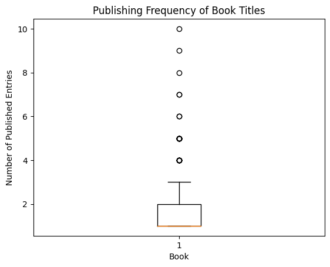

```python
plt.boxplot(book_titles)
plt.title('Publishing Frequency of Book Titles')
plt.xlabel('Book')
plt.ylabel('Number of Published Entries')

plt.show()
```

**Observations**

### Most Frequent Book Titles

Based on our previous observation, we will define 'most frequent' as any book title that appears 3 or more times during the time period of 2009-2019.

```python
mask_book_tiles = book_titles > 2
books_most_frequent = book_titles[mask_book_tiles]

print(len(books_most_frequent), 'book titles appear 3 or more times')
print(books_most_frequent)
```

```
41 book titles appear 3 or more times
Publication Manual of the American Psychological Association, 6th Edition                            10
StrengthsFinder 2.0                                                                                   9
Oh, the Places You'll Go!                                                                             8
The Very Hungry Caterpillar                                                                           7
The 7 Habits of Highly Effective People: Powerful Lessons in Personal Change                          7
The Four Agreements: A Practical Guide to Personal Freedom (A Toltec Wisdom Book)                     6
Jesus Calling: Enjoying Peace in His Presence (with Scripture References)                             6
The Official SAT Study Guide                                                                          5
To Kill a Mockingbird                                                                                 5
The 5 Love Languages: The Secret to Love That Lasts                                                   5
The 5 Love Languages: The Secret to Love that Lasts                                                   5
Laugh-Out-Loud Jokes for Kids                                                                         5
How to Win Friends & Influence People                                                                 5
Unbroken: A World War II Story of Survival, Resilience, and Redemption                                5
The Five Dysfunctions of a Team: A Leadership Fable                                                   5
Giraffes Can't Dance                                                                                  5
Wonder                                                                                                5
First 100 Words                                                                                       5
The Fault in Our Stars                                                                                4
Dear Zoo: A Lift-the-Flap Book                                                                        4
The Wonderful Things You Will Be                                                                      4
The Life-Changing Magic of Tidying Up: The Japanese Art of Decluttering and Organizing                4
Good to Great: Why Some Companies Make the Leap and Others Don't                                      4
Thug Kitchen: The Official Cookbook: Eat Like You Give a F*ck (Thug Kitchen Cookbooks)                4
The Help                                                                                              4
You Are a Badass: How to Stop Doubting Your Greatness and Start Living an Awesome Life                4
Knock-Knock Jokes for Kids                                                                            3
Catching Fire (The Hunger Games)                                                                      3
Game of Thrones Boxed Set: A Game of Thrones/A Clash of Kings/A Storm of Swords/A Feast for Crows     3
Gone Girl                                                                                             3
The Day the Crayons Quit                                                                              3
Goodnight Moon                                                                                        3
The Immortal Life of Henrietta Lacks                                                                  3
The Subtle Art of Not Giving a F*ck: A Counterintuitive Approach to Living a Good Life                3
Player's Handbook (Dungeons & Dragons)                                                                3
Milk and Honey                                                                                        3
The Whole30: The 30-Day Guide to Total Health and Food Freedom                                        3
Mindset: The New Psychology of Success                                                                3
Crazy Love: Overwhelmed by a Relentless God                                                           3
Mockingjay (The Hunger Games)                                                                         3
The Great Gatsby                                                                                      3
Name: Name, dtype: int64
```

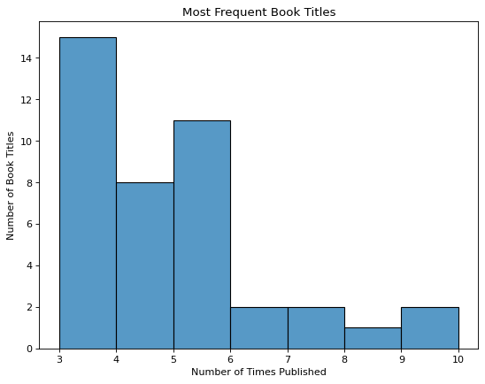

```python
plt.figure(figsize=(8,6), dpi=80)
sns.histplot(data=books_most_frequent, bins='auto', binwidth=1)

plt.title('Most Frequent Book Titles')
plt.xlabel('Number of Times Published')
plt.ylabel('Number of Book Titles')

plt.show()
```

### Top 10 Book Titles

```python
top_ten_books = books_most_frequent.head(10)
print(top_ten_books)
```

```
Publication Manual of the American Psychological Association, 6th Edition            10
StrengthsFinder 2.0                                                                   9
Oh, the Places You'll Go!                                                             8
The Very Hungry Caterpillar                                                           7
The 7 Habits of Highly Effective People: Powerful Lessons in Personal Change          7
The Four Agreements: A Practical Guide to Personal Freedom (A Toltec Wisdom Book)     6
Jesus Calling: Enjoying Peace in His Presence (with Scripture References)             6
The Official SAT Study Guide                                                          5
To Kill a Mockingbird                                                                 5
The 5 Love Languages: The Secret to Love That Lasts                                   5
Name: Name, dtype: int64
```

##### Bar plot

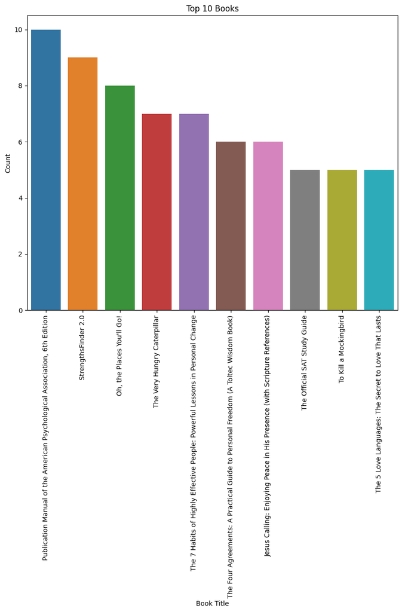

```python
# convert series to data frame
top_ten_books_df = pd.DataFrame({'Name': top_ten_books.index, 'Count': top_ten_books.values})

# create bar plot of data frame
plt.figure(figsize=(10,8))
sns.barplot(data=top_ten_books_df, x='Name', y='Count')
plt.title('Top 10 Books')
plt.xlabel('Book Title')
plt.xticks(rotation=90)
plt.ylabel('Count')

plt.show()
```

```python
list_of_top_ten_books = top_ten_books.index.tolist()

df_top_10_books = df[df['Name'].isin(list_of_top_ten_books)]

df_top_10_books
```

|  | Name | Author | User Rating | Reviews | Price | Year | Genre |
| --- | --- | --- | --- | --- | --- | --- | --- |
| 187 | Jesus Calling: Enjoying Peace in His Presence ... | Sarah Young | 4.9 | 19576 | 8 | 2011 | Non Fiction |
| 188 | Jesus Calling: Enjoying Peace in His Presence ... | Sarah Young | 4.9 | 19576 | 8 | 2012 | Non Fiction |
| 189 | Jesus Calling: Enjoying Peace in His Presence ... | Sarah Young | 4.9 | 19576 | 8 | 2013 | Non Fiction |
| 190 | Jesus Calling: Enjoying Peace in His Presence ... | Sarah Young | 4.9 | 19576 | 8 | 2014 | Non Fiction |
| 191 | Jesus Calling: Enjoying Peace in His Presence ... | Sarah Young | 4.9 | 19576 | 8 | 2015 | Non Fiction |
| ... | ... | ... | ... | ... | ... | ... | ... |
| 505 | To Kill a Mockingbird | Harper Lee | 4.8 | 26234 | 0 | 2013 | Fiction |
| 506 | To Kill a Mockingbird | Harper Lee | 4.8 | 26234 | 0 | 2014 | Fiction |
| 507 | To Kill a Mockingbird | Harper Lee | 4.8 | 26234 | 0 | 2015 | Fiction |
| 508 | To Kill a Mockingbird | Harper Lee | 4.8 | 26234 | 0 | 2016 | Fiction |
| 509 | To Kill a Mockingbird | Harper Lee | 4.8 | 26234 | 7 | 2019 | Fiction |

68 rows × 7 columns

#### Top Book: Publication Manual of the American Psychological Association, 6th Edition

```python
df.loc[df['Name']=='Publication Manual of the American Psychological Association, 6th Edition']
```

|  | Name | Author | User Rating | Reviews | Price | Year | Genre |
| --- | --- | --- | --- | --- | --- | --- | --- |
| 271 | Publication Manual of the American Psychologic... | American Psychological Association | 4.5 | 8580 | 46 | 2009 | Non Fiction |
| 272 | Publication Manual of the American Psychologic... | American Psychological Association | 4.5 | 8580 | 46 | 2010 | Non Fiction |
| 273 | Publication Manual of the American Psychologic... | American Psychological Association | 4.5 | 8580 | 46 | 2011 | Non Fiction |
| 274 | Publication Manual of the American Psychologic... | American Psychological Association | 4.5 | 8580 | 46 | 2012 | Non Fiction |
| 275 | Publication Manual of the American Psychologic... | American Psychological Association | 4.5 | 8580 | 46 | 2013 | Non Fiction |
| 276 | Publication Manual of the American Psychologic... | American Psychological Association | 4.5 | 8580 | 46 | 2014 | Non Fiction |
| 277 | Publication Manual of the American Psychologic... | American Psychological Association | 4.5 | 8580 | 46 | 2015 | Non Fiction |
| 278 | Publication Manual of the American Psychologic... | American Psychological Association | 4.5 | 8580 | 46 | 2016 | Non Fiction |
| 279 | Publication Manual of the American Psychologic... | American Psychological Association | 4.5 | 8580 | 46 | 2017 | Non Fiction |
| 280 | Publication Manual of the American Psychologic... | American Psychological Association | 4.5 | 8580 | 46 | 2018 | Non Fiction |

```python
for book in list_of_top_ten_books:
    print(book)
```

```
Publication Manual of the American Psychological Association, 6th Edition
StrengthsFinder 2.0
Oh, the Places You'll Go!
The Very Hungry Caterpillar
The 7 Habits of Highly Effective People: Powerful Lessons in Personal Change
The Four Agreements: A Practical Guide to Personal Freedom (A Toltec Wisdom Book)
Jesus Calling: Enjoying Peace in His Presence (with Scripture References)
The Official SAT Study Guide
To Kill a Mockingbird
The 5 Love Languages: The Secret to Love That Lasts
```

**Observations**

Top 10 most common book titles:

- Publication Manual of the American Psychological Association, 6th - Edition
- StrengthsFinder 2.0
- Oh, the Places You'll Go!
- The Very Hungry Caterpillar
- The 7 Habits of Highly Effective People: Powerful Lessons in Personal - Change
- The Four Agreements: A Practical Guide to Personal Freedom (A Toltec - Wisdom Book)
- Jesus Calling: Enjoying Peace in His Presence (with Scripture - References)
- The Official SAT Study Guide
- To Kill a Mockingbird
- The 5 Love Languages: The Secret to Love That Lasts

### Analysis Conclusions

After the analysis, it's time to reflect on what was observed in the data. Let's look at our investigative questions and the answers yielded by our analysis.

## References

- [Data Source: Kaggle](https://www.kaggle.com/datasets/sootersaalu/amazon-top-50-bestselling-books-2009-2019?datasetId=918976&sortBy=dateRun&tab=profile)
- [Why Does The Amazon Book Market Share Dominate The Market?](https://justpublishingadvice.com/why-do-amazon-sell-more-ebooks-than-other-retailers/)

## Contact

- Email
- [LinkedIn](https://www.linkedin.com/in/anthonynanfito/)
- [GitHub](https://www.github.com/ananfito)
- [Portfolio](https://ananfito.github.io)